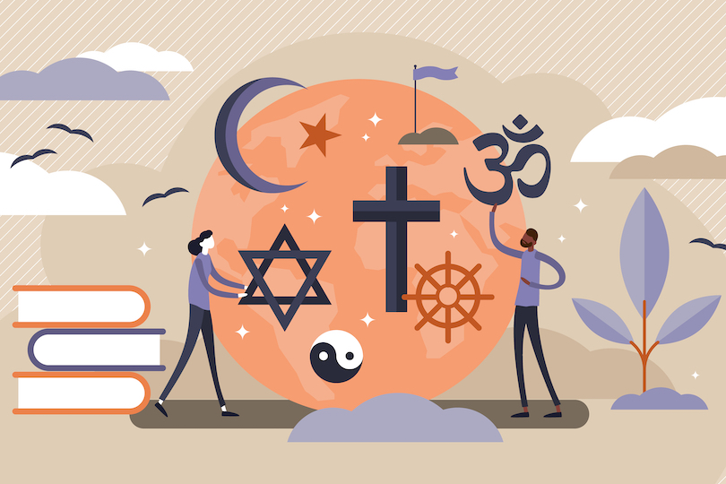

# Religion in Philosophy

Throughout history, humanity's relationship with religion and different belief systems has been a core part of our internal conflict and identity. As a concept that is typically less immediately physical but more relevant to us spiritually and mentally, it is only natural to find value in looking at religion through philisophical schools throughout time. Not only do they often address religion and humanity's relationship with religion on its own, religion is intrinsically connected to and can shape our values, so a school of thought's perspective on religion can unveil other aspects of the school.

In this data analysis project, we take a look at an extensive collection of philisophical text data which span 13 schools of thought. Specifically, we have Plato, Aristotle, Nietzsche, Rationalism, Empiricism, German Idealism, Communism, Capitalism, Phenomenology, Continental Philosophy, Analytic Philosophy, Feminism, and Stoicism. Through this data, we will look at how these schools view religion and analyze their sentiment. We will aim to answer questions about the extent of their sentiment on religion and their perspective on it.

## Housekeeping

We first install some immediately relevant libraries, observe current Python version, and read the data into the notebook. Jump to "Preliminary Data Exploration" to see actual observations of the philosophy data.

```python
import sys
import numpy as np
import pandas as pd
```

```python
print(sys.version)
```

```
3.10.4 (main, Mar 31 2022, 03:38:35) [Clang 12.0.0 ]
```

```python
path = '../../../../Downloads/philosophy_data.csv' #alter path for own dataset file path
phi_data = pd.read_csv(path)
```

```python
pd.options.display.max_colwidth = 75
phi_data.sample(3)
```

|  | title | author | school | sentence_spacy | sentence_str | original_publication_date | corpus_edition_date | sentence_length | sentence_lowered | tokenized_txt | lemmatized_str |
| --- | --- | --- | --- | --- | --- | --- | --- | --- | --- | --- | --- |
| 267298 | Science Of Logic | Hegel | german_idealism | It therefore constitutes the first sequel to the Phenomenology of Spiri... | It therefore constitutes the first sequel to the Phenomenology of Spiri... | 1817 | 2010 | 118 | it therefore constitutes the first sequel to the phenomenology of spiri... | ['it', 'therefore', 'constitutes', 'the', 'first', 'sequel', 'to', 'the... | -PRON- therefore constitute the first sequel to the Phenomenology of S... |
| 308678 | The Wealth Of Nations | Smith | capitalism | It is not the actual greatness of national wealth, but its continual in... | It is not the actual greatness of national wealth, but its continual in... | 1776 | 2009 | 125 | it is not the actual greatness of national wealth, but its continual in... | ['it', 'is', 'not', 'the', 'actual', 'greatness', 'of', 'national', 'we... | -PRON- be not the actual greatness of national wealth , but -PRON- con... |
| 351183 | The Second Sex | Beauvoir | feminism | I am arch, gay, languid, melancholy by turns; I am rooted, but I flow. | I am arch, gay, languid, melancholy by turns; I am rooted, but I flow. | 1949 | 2009 | 70 | i am arch, gay, languid, melancholy by turns; i am rooted, but i flow. | ['am', 'arch', 'gay', 'languid', 'melancholy', 'by', 'turns', 'am', 'ro... | -PRON- be arch , gay , languid , melancholy by turn ; -PRON- be root ,... |

# Preliminary Data Exploration

To explain and prepare for potential issues to come for this analysis, we first explore the data and display information which is relevant to future analysis.

To analyze these philosophical texts, it would help to get a clear picture in how many sentences from each school we have to work with. This way, it will be easier to determine whether we have enough data can come to any conclusions about specific schools relative to other schools.

```python
phi_data.loc[:,"school"].value_counts()
```

```
analytic           55425
aristotle          48779
german_idealism    42136
plato              38366
continental        33779
phenomenology      28573
rationalism        22949
empiricism         19931
feminism           18635
capitalism         18194
communism          17958
nietzsche          13548
stoicism            2535
Name: school, dtype: int64
```

As we can see, each school has at least 10,000 sentences except for stoicism, which has 2,535. For the most part, there is a lot of data to work with for each school. However, we must take care when considering analysis for stoicism because of its relative lack of data.

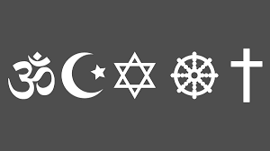

# Observing schools' relationship with religion

Now we properly assess the schools of though in regards to religion. We will do so in 2 ways:

- run a sentiment analysis on a subset of schools to determine how positive or negative they perceive religion
- we construct word clouds from sentences surrounding religion to determine the most common language and perspectives they use in relation

## How positive or negative do these schools perceive religion and religion-adjacent concepts?

To hone in on schools of interest, we will only look at a subset of the options for schools of thought. Specifically, I have selected Feminism, Capitalism, Communism, Nietzshe, Analytic Philosophy, and Continental Philosophy. I chose the first three because they are the most well-known and relevant schools among the modern population, especially those who are not familiar with philosophy. Nietzshe is very famously known as an atheist and preaches as such, so it would be good to see how this assessment views Nietzshe in sentiment relative to the other schools. Finally, Analytical and Continental Philosophies are often pitted against one another and immediately conflict, so there is the interest in seeing the contrast between their perspectives on religion.

```python
import nltk
```

```python
nltk.download(['stopwords','vader_lexicon']) #download aspects of nltk needed for cleaning and analysis
from nltk.corpus import stopwords
from nltk.sentiment import SentimentIntensityAnalyzer
```

In order to analyze the most commonly used words around religion for each school, we remove stop words, or common words and characters which don't alter meaning in a sentence (e.g. at, to) and turn the table of sentences into a long list of all of the words in the sentences in order.

```python
stop_words = set(stopwords.words('english')+['-pron-',',','.',';',':','?','!','-','--'])
```

```python
def concat_clean_words(school): #returns list of words from specified school in order
    cond = phi_data.loc[:,'school'] == school
    text = ' '.join(phi_data.loc[cond,'lemmatized_str']) #lemmatized for word cloud later
    text_tokens = text.split()
    return [word.lower() for word in text_tokens if word.lower() not in stop_words]
```

Using the function to retrieve that long list of words, now we create a function to apply sentiment analysis on that list and retrieve an average sentiment for words surrounding any specified topic. In this case, we are most interested in religion and God. God is useful for this case as Christianity is by far the more prevalent religion throughout, so philisophical texts consistently address God from Christianity. Additionally, many of these are Western philosophies, so Christianity is especially relevant.

```python
sia = SentimentIntensityAnalyzer()

def avg_sentiment_context(school,word): #returns average sentiment for context around specified word
    text = nltk.Text(concat_clean_words(school))
    conc_list = text.concordance_list(word,lines = 500)
    neg,neu,pos = 0,0,0
    n = len(conc_list)
    for i in range(n):
        sent_score = sia.polarity_scores(conc_list[i].line)
        neg += sent_score['neg']
        neu += sent_score['neu']
        pos += sent_score['pos']
    return {'neg': neg/n, 'neu': neu/n, 'pos': pos/n}
```

We will use 'God' as our topic of interest for each school.

```python
schools = ['feminism', 'capitalism', 'communism','nietzsche', 'analytic', 'continental']
neg_means = []
neu_means = []
pos_means = []
for school in schools:
    sent_dict = avg_sentiment_context(school,'God')
    neg_means.append(sent_dict['neg'])
    neu_means.append(sent_dict['neu'])
    pos_means.append(sent_dict['pos'])
```

We visualize the average sentiments using a bar graph.

```python
import matplotlib.pyplot as plt
import seaborn as sns
```

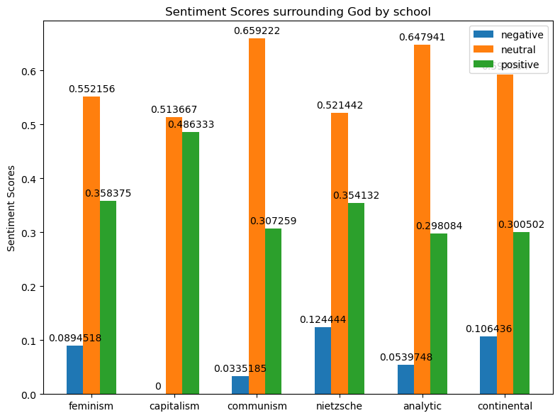

```python
fig, ax = plt.subplots(figsize=(8,6))

x = np.arange(len(schools))
width = 0.2

rects1 = ax.bar(x - width, neg_means, width, label='negative')
rects2 = ax.bar(x, neu_means, width, label='neutral')
rects3 = ax.bar(x + width, pos_means, width, label='positive')

ax.set_ylabel('Sentiment Scores')
ax.set_title('Sentiment Scores surrounding God by school')
ax.set_xticks(x, schools)
ax.legend()

ax.bar_label(rects1, padding=3)
ax.bar_label(rects2, padding=3)
ax.bar_label(rects3, padding=3)

fig.tight_layout()
plt.show()
```

To be sure, we use 'religion' below to see if there are any differences in the schools' language.

```python
neg_means = []
neu_means = []
pos_means = []
for school in schools:
    sent_dict = avg_sentiment_context(school,'religion')
    neg_means.append(sent_dict['neg'])
    neu_means.append(sent_dict['neu'])
    pos_means.append(sent_dict['pos'])
```

[figure not shown]

```python
fig, ax = plt.subplots(figsize=(8,6))

x = np.arange(len(schools))
width = 0.2

rects1 = ax.bar(x - width, neg_means, width, label='negative')
rects2 = ax.bar(x, neu_means, width, label='neutral')
rects3 = ax.bar(x + width, pos_means, width, label='positive')

ax.set_ylabel('Sentiment Scores')
ax.set_title('Sentiment Scores surrounding God by school')
ax.set_xticks(x, schools)
ax.legend()

ax.bar_label(rects1, padding=3)
ax.bar_label(rects2, padding=3)
ax.bar_label(rects3, padding=3)

fig.tight_layout()
plt.show()
```

The neutral scores here are much higher in general. This could be because these texts discuss the word "religion" more often in more objective cases unrelated to their own schools of thought.

## What are the most common words these schools associate with God and religion?

Now we will create word clouds to visualize the most common words these texts associate with God.

```python
from wordcloud import WordCloud, STOPWORDS, ImageColorGenerator
```

```python
def word_cloud_synth(school,word): #synthesizes word cloud of context from data, inputting school and topic of interest
    text = nltk.Text(concat_clean_words(school))
    conc_list = text.concordance_list(word,lines = 500)
    conc_act_list = [conc_list[i].line for i in range(len(conc_list))]
    long_str = ' '.join(conc_act_list)
    return WordCloud().generate(long_str.replace('god','')) #remove God from cloud to showcase surrounding words
```

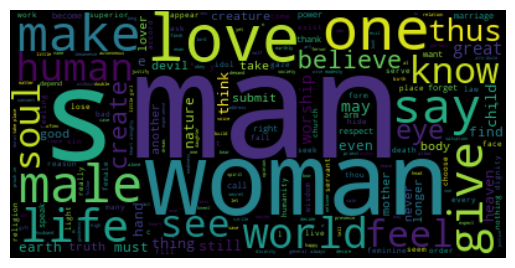

```python
plt.imshow(word_cloud_synth('feminism','God'), interpolation='bilinear')
plt.axis("off")
plt.show()
```

In relation to religion and Christian God, the most common words seen are "man", "woman", "love", "one", and "male". As a school which is very interested in the relationships between gender and society, we can see that this school also perceives Christian God through the lense of gender and sex.

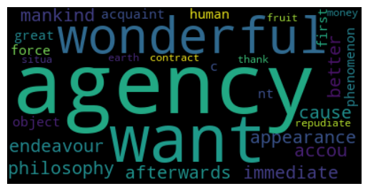

```python
plt.imshow(word_cloud_synth('capitalism','God'), interpolation='bilinear')
plt.axis("off")
plt.show()
```

Capitalism's most common words seem to be "agency", "want", "wonderful", "appearance", and "immediate". This is a sharp contrast to the gender lens that Feminism looked at through God. Here, there seems to be a stronger connection to humanity's free will and desires. Capitilism is about private parties owning and controlling property according to their desires. From this cloud, we can see these general values reflected in their contexts for religion. The more sparse word cloud confirms that there are less mentions of "God" in these texts compared to the other schools.

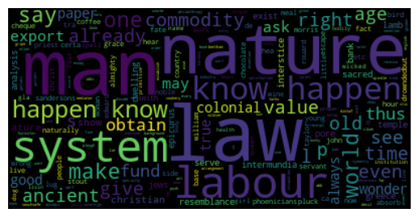

```python
plt.imshow(word_cloud_synth('communism','God'), interpolation='bilinear')
plt.axis("off")
plt.show()
```

Communism seems to connect God to the words "labour", "man", "law", "nature", and "system". Intrinsically, communism is interested in the labor of man and systematic government, so there is a connection between that and the perspectives for religion. As we know it, communism insists on a classless society and common, public ownership of mortal entities. This certainly reflects that.

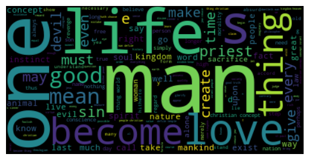

```python
plt.imshow(word_cloud_synth('nietzsche','God'), interpolation='bilinear')
plt.axis("off")
plt.show()
```

Nietzsche, the man who's philosophical thoughts are largely centered around the lack of faith in religion (and has a text called "God is Dead"), has the most common words associated as "one", "man", "life", "love", and "become". Man here most likely refers to people in general, and not as in gendered men. His views from this initial understanding are not so evident is this word cloud as they are for the others. However, they do showcase how he likely discussed the basis of love, life, and good in the context of God, whether in a pessimistic perspective or not.

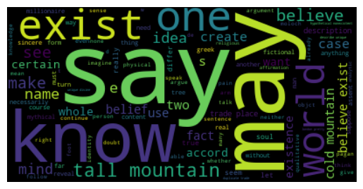

```python
plt.imshow(word_cloud_synth('analytic','God'), interpolation='bilinear')
plt.axis("off")
plt.show()
```

The most common words for Analytic Philosophy are "say", "may", "know", "exist", and "one". The core aspects of this field are the focuses on analytics of thought, knowledge, logic, and language. This is clearly reflected with words like "say" for language and "know" for knowledge and thought. This paints a picture of the texts looking at God through the lens of analytical language and thought.

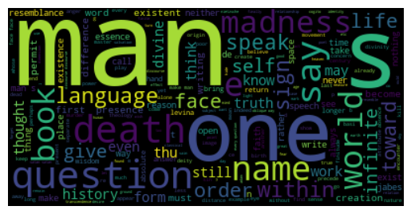

```python
plt.imshow(word_cloud_synth('continental','God'), interpolation='bilinear')
plt.axis("off")
plt.show()
```

The most common words for Continental Philosophy are "man", "one", "question", "death", "madness", and "saw". This is fairly different than Analytic Philosophy. This makes sense, as Continental Philosophy is often seen as the category which cover miscellaneous views which clearly differ from Analytic Philosophy. It's more interested in our perceptions and historical viewpoints, sometimes reject natural sciences. The more charged common words reflect this nature.

# Conclusion

From this analysis, we gained a much clearer understanding of the selected schools of thought regarding religion, at least relative to each other.

For Communism, the bar graph showed the most neutral perspective and discussion of God. Additionally, the word cloud showcased words surrounding systems and labor, which align with the government ideas that Communism support.

For Analytic vs. Continental, the Analytic had a very neutral viewpoint on God and religion, whereas Continental had more negative inclinations. Regarding their respective word clouds, Analytic focused on God through knowledge and language, whereas Continental had a perspective that rejected the analytical approach of view God (so closer to the ideas of death and questions).